# Cotiviti Data Scientist I Assessment

# **Importing Libraries**

```python
import numpy as np
import pandas as pd
import matplotlib.pyplot as plt
import seaborn as sns
from sklearn.model_selection import train_test_split
import statsmodels.api as sm
from sklearn.linear_model import LinearRegression
from sklearn.metrics import mean_squared_error
from sklearn.metrics import r2_score
from scipy import stats
from sklearn.preprocessing import PowerTransformer
```

# **Data Loading**

```python
df = pd.read_csv('ASSESSMENT_DATA.csv')
```

```python
df.head()
```

|  | Unnamed: 0 | X | Y |
| --- | --- | --- | --- |
| 0 | 0 | 0.113169 | -0.267085 |
| 1 | 1 | 3.301015 | 12.945851 |
| 2 | 2 | 3.999341 | 16.419243 |
| 3 | 3 | 3.288918 | 6.950318 |
| 4 | 4 | 2.760255 | -4.311010 |

```python
df.drop(columns='Unnamed: 0', inplace=True)
```

```python
df.head()
```

|  | X | Y |
| --- | --- | --- |
| 0 | 0.113169 | -0.267085 |
| 1 | 3.301015 | 12.945851 |
| 2 | 3.999341 | 16.419243 |
| 3 | 3.288918 | 6.950318 |
| 4 | 2.760255 | -4.311010 |

```python
print('Shape of the data', df.shape)
```

```
Shape of the data (500, 2)
```

```python
# Information about the data including data type

df.info()
```

```
<class 'pandas.core.frame.DataFrame'>
RangeIndex: 500 entries, 0 to 499
Data columns (total 2 columns):
 #   Column  Non-Null Count  Dtype
---  ------  --------------  -----
 0   X       500 non-null    float64
 1   Y       500 non-null    float64
dtypes: float64(2)
memory usage: 7.9 KB
```

# **Data Exploration**

```python
# There are no missing values in the data

df.isnull().sum()
```

```
X    0
Y    0
dtype: int64
```

```python
# Summary Statistics for the data

df.describe()
```

|  | X | Y |
| --- | --- | --- |
| count | 500.000000 | 500.000000 |
| mean | 2.369100 | 5.156025 |
| std | 1.449450 | 6.336472 |
| min | 0.006334 | -7.818190 |
| 25% | 1.037073 | 0.208644 |
| 50% | 2.329645 | 4.002993 |
| 75% | 3.639699 | 8.665190 |
| max | 4.998945 | 32.883796 |

```python
# Checking the skewness value for the data

df.skew()
```

```
X    0.060003
Y    0.956970
dtype: float64
```

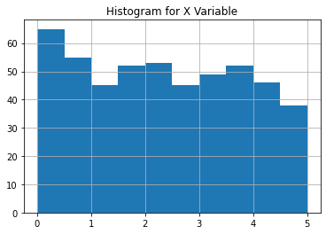

```python
# Checking the distribution of X variable through Histogram

df.X.hist()
plt.title('Histogram for X Variable')
```

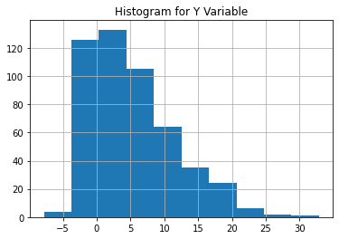

```python
# Checking the distribution of Y variable through Histogram

df.Y.hist()
plt.title('Histogram for Y Variable')
```

The Dependent Variable (Y) looks right skewed with a long right tail

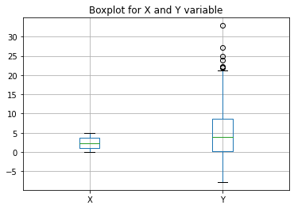

```python
# Boxplot to see if there are any outliers

df.boxplot()
plt.title('Boxplot for X and Y variable')
```

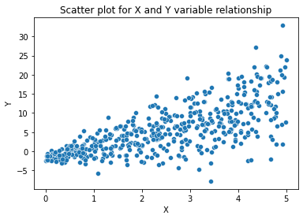

```python
# Scatter plot to depict the relationship between the X and the Y variable

sns.scatterplot(data=df,x='X', y='Y')
plt.title('Scatter plot for X and Y variable relationship')
plt.show()
```

**From the scatter plot, it can be seen that there is linearity in the data. As the X variable increases, Y increases.**

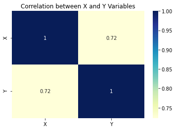

```python
# Correlation between the X and the Y variables

sns.heatmap(df.corr(), cmap="YlGnBu", annot = True)
plt.title('Correlation between X and Y Variables')
plt.show()
```

From the correlation plot, it can be seen that the Dependent Variable (Y) is highly positively correlated with the Independent Variable (X) with a correlation coefficient of 0.72.

# **Statsmodel Library for Simple Linear Regression**

```python
# Defining the X and the y variables

X = df['X']
y = df['Y']
```

```python
# Splitting the data into train and test with training size 0.7 and test data size 0.3

X_train, X_test, y_train, y_test = train_test_split(X, y, train_size = 0.7, test_size = 0.3, random_state = 100)
```

```python
# Adding the constant term for the intercept
X_train_sm = sm.add_constant(X_train)

# Fit the resgression line using 'OLS'
lr = sm.OLS(y_train, X_train_sm).fit()
```

```python
# Intercept and slope values

lr.params
```

```
const   -2.279961
X        3.177163
dtype: float64
```

```python
# Printing the detailed summary of the linear regression model built

print(lr.summary())
```

```
                            OLS Regression Results
==============================================================================
Dep. Variable:                      Y   R-squared:                       0.523
Model:                            OLS   Adj. R-squared:                  0.522
Method:                 Least Squares   F-statistic:                     381.7
Date:                Fri, 06 Aug 2021   Prob (F-statistic):           6.58e-58
Time:                        19:48:11   Log-Likelihood:                -1016.4
No. Observations:                 350   AIC:                             2037.
Df Residuals:                     348   BIC:                             2044.
Df Model:                           1
Covariance Type:            nonrobust
==============================================================================
                 coef    std err          t      P>|t|      [0.025      0.975]
------------------------------------------------------------------------------
const         -2.2800      0.446     -5.109      0.000      -3.158      -1.402
X              3.1772      0.163     19.537      0.000       2.857       3.497
==============================================================================
Omnibus:                       18.120   Durbin-Watson:                   2.041
Prob(Omnibus):                  0.000   Jarque-Bera (JB):               49.997
Skew:                           0.035   Prob(JB):                     1.39e-11
Kurtosis:                       4.850   Cond. No.                         5.68
==============================================================================

Notes:
[1] Standard Errors assume that the covariance matrix of the errors is correctly specified.
```

# Interpretations and Insights from the Regression Model

1. Ordinary Least Square method is used to fit the trend line.
1. R-squared of the model is 0.523 which means that 52.3% of the variance in the Y variable can be explained by X variable.
1. Prob (F-statistic) shows that the regression equation is statistically significant and not by random chance.
1. The intercept and slope values for the trend line are -2.28 and 3.177 respectively both being statistically significant and important as the p-value is very low.
1. With 95% Confidence (CI), we can say that intercept lies between -3.158 and -1.402 for the population.
1. Similarly, for the slope the true population value lies between 2.857 and 3.497. As for both intercept and slope, the CI range values do not cross 0 so we can say that this the true range for the population and are conclusive.
1. The Standard Error for intercept and slope is 0.446 and 0.163 respectively which the average distance deviation of the points from the model.
1. Interpretation of Slope: For every 1 unit increase in X, the corresponding predicted Y variable increases by 3.1772 units.
1. Interpretation of Intercept: Without any X variable value, we still have Y value to be -2.28 which is a predicted value.
1. Almost Normally Distributed as skew is 0.035, with more peak than the normal distribution seen from Kurtosis value.

**11. Equation of Trend Line: Y^ (Yhat predicted) = -2.28 + 3.1772*X**

1. Slope (X coefficient) is positive meaning it will always increase the predicted y value.

```python
# Predicting the Y values using the Linear Regression model built along with it calculating the residuals for the train data

y_train_pred = lr.predict(X_train_sm)
res = (y_train - y_train_pred)
```

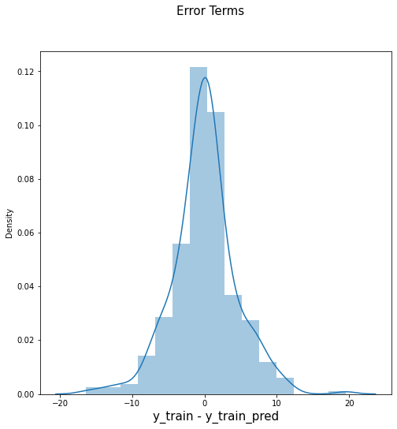

```python
# Plotting the distribution of the residuals to check for Normality

fig = plt.figure(figsize=(8,8))
sns.distplot(res, bins = 15)
fig.suptitle('Error Terms', fontsize = 15)
plt.xlabel('y_train - y_train_pred', fontsize = 15)
plt.show()
```

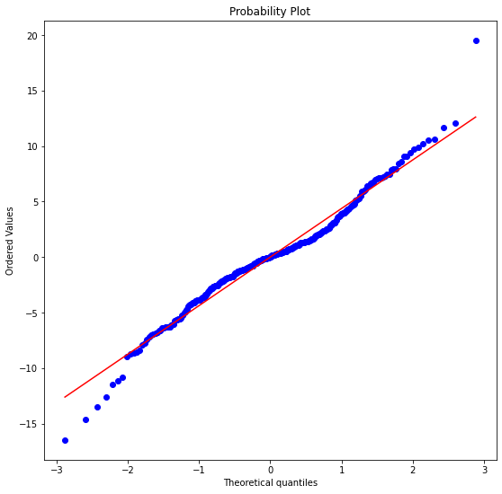

```python
# Q-Q plot for the residuals to check the normality

plt.figure(figsize=(9,9))

stats.probplot(res, dist="norm", plot=plt);
```

```python
# Adding the intercept for the test data
X_test_sm = sm.add_constant(X_test)

# Predict the y values corresponding to X_test_sm
y_pred = lr.predict(X_test_sm)
```

```python
# Calculating the RMSE for the test data

print('RMSE for the test data is', np.sqrt(mean_squared_error(y_test, y_pred)))
```

```
RMSE for the test data is 4.271801590352114
```

```python
# Calculating the R Squared value for the Linear Regression

r_squared = r2_score(y_test, y_pred)
r_squared
```

```
0.5220648233282453
```

1. RMSE for the regression model is 4.27.
1. R squared value is the same as we got from the regression model output of 52.3 % variability in Y variable is explained by X variable.
1. R2 for both train and test data is same meaning model performs equally well on both the train and test data.

# **Sklearn Linear Regression**

```python
# Initialise the regressor and fit the training data

regressor = LinearRegression()
regressor.fit(np.array(X_train).reshape(-1, 1), np.array(y_train))

#Predicting the Y variable
pred = regressor.predict(np.array(X_test).reshape(-1, 1))
```

```python
# Check trained model y-intercept
print(regressor.intercept_)

# Check trained model coefficient
print(regressor.coef_)
```

```
-2.2799613682658117
[3.17716325]
```

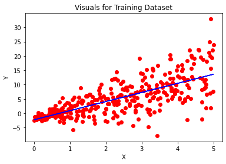

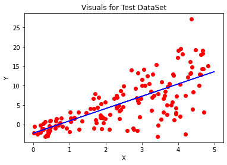

```python
#Visualizing the training Test Results
plt.scatter(X_train, y_train, color= 'red')
plt.plot(X_train, regressor.predict(np.array(X_train).reshape(-1, 1)), color = 'blue')
plt.title ("Visuals for Training Dataset")
plt.xlabel("X")
plt.ylabel("Y")
plt.show()

#Visualizing the Test Results
plt.scatter(X_test, y_test, color= 'red')
plt.plot(X_train, regressor.predict(np.array(X_train).reshape(-1, 1)), color = 'blue')
plt.title("Visuals for Test DataSet")
plt.xlabel("X")
plt.ylabel("Y")
plt.show()
```

```python
print('RMSE for test data for Sklearn model is ', np.sqrt(mean_squared_error(pred, y_test)))
```

```
RMSE for test data for Sklearn model is  4.271801590352114
```

```python
print('R2 for the Sklearn library model is', r2_score(y_test, pred))
```

```
R2 for the Sklearn library model is 0.5220648233282454
```

# Interpretations and Insights from the Sklearn Model

1. Equation of the trend line is the same as obtained from the statsmodel

   **Y^ (Yhat Predicted) = -2.28 + 3.177 * X**
1. RMSE and R squared values are also same as obtained from the Statsmodel library regression.

# **Transforming Dependent Variable for Skewness and Applying Regression Model**

As it can be seen from the skewness value and boxplot, the dependent variable needs to be transformed in some manner to bring it to a Normally Distributed Form to apply a large number of tests which require Normality. To do this, we can use Box Cox Transformation to find the lambda value for us to decide what transformation needs to be performed on the dependent variable.

Box Cox Transformation works only for the positive values and not for negative values. So, for this data Box Cox Transformation won't work. Instead of it, we can use Yeo-Johnson Transformation method using PowerTransformer from the sklearn preprocessing module to work with negative values.

Power Transform will transform the Dependent data automatically instead of finding the lambda value and manually transforming it.

```python
# Initializing the power transformer

pt = PowerTransformer()
```

```python
# Fitting the Power Transformer to the Dependent variable

pt.fit(np.array(df['Y']).reshape(-1, 1))
```

```
PowerTransformer()
```

```python
# Lambda value for the Yeo-johnson method used

print(pt.lambdas_)
```

```
[0.65912139]
```

```python
# Creating new column with Power Transformed Dependent Variable Y for Regression

df['trans_y'] = pt.transform(np.array(df['Y']).reshape(-1, 1))
```

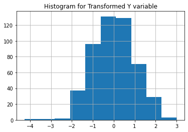

```python
# Histogram of Transformed Y variable

df['trans_y'].hist()
plt.title('Histogram for Transformed Y variable')
```

```python
df['trans_y'].skew()
```

```
-0.07662791049841584
```

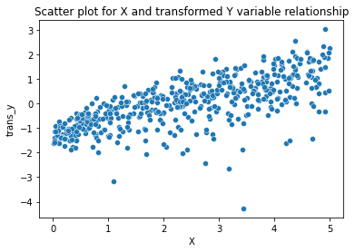

```python
# Scatter plot to depict the relationship between the X and the Transformed Y variable

sns.scatterplot(data=df,x='X', y='trans_y')
plt.title('Scatter plot for X and transformed Y variable relationship')
plt.show()
```

From the histogram and the skewness value, we can see that the Dependent Variable is Normally Distributed.

From the scatter plot, it can be seen that after transformation the relationship between Y and X variables becomes more compact and looks likes following a straight line.

## Model Building for Transformed Y using Statsmodel Library Linear Regression

```python
# Defining the X and the y variables for the Regression Analysis

X = df['X']
y_trans = df[['trans_y','Y']]
```

```python
# Splitting the data into train and test with training size 0.7 and test data size 0.3

X_train_trans, X_test_trans, y_train_trans, y_test_trans = train_test_split(X, y_trans, train_size = 0.7, test_size = 0.3, random_state = 100)
```

```python
# Adding the constant term for the intercept
X_train_sm_trans = sm.add_constant(X_train_trans)

# Fit the resgression line using 'OLS' with only Transformed data for dependent variable leaving out the original dependent variable
lr = sm.OLS(y_train_trans.drop(columns='Y',axis=1), X_train_sm_trans).fit()
```

```python
# Intercept and slope values for Transformed Dependent variable

lr.params
```

```
const   -1.143689
X        0.486235
dtype: float64
```

```python
# Printing the detailed summary of the linear regression model built on Transformed Dependent variable

print(lr.summary())
```

```
                            OLS Regression Results
==============================================================================
Dep. Variable:                trans_y   R-squared:                       0.483
Model:                            OLS   Adj. R-squared:                  0.482
Method:                 Least Squares   F-statistic:                     325.6
Date:                Fri, 06 Aug 2021   Prob (F-statistic):           7.58e-52
Time:                        19:48:14   Log-Likelihood:                -387.24
No. Observations:                 350   AIC:                             778.5
Df Residuals:                     348   BIC:                             786.2
Df Model:                           1
Covariance Type:            nonrobust
==============================================================================
                 coef    std err          t      P>|t|      [0.025      0.975]
------------------------------------------------------------------------------
const         -1.1437      0.074    -15.468      0.000      -1.289      -0.998
X              0.4862      0.027     18.044      0.000       0.433       0.539
==============================================================================
Omnibus:                      140.340   Durbin-Watson:                   2.157
Prob(Omnibus):                  0.000   Jarque-Bera (JB):              763.330
Skew:                          -1.602   Prob(JB):                    1.76e-166
Kurtosis:                       9.486   Cond. No.                         5.68
==============================================================================

Notes:
[1] Standard Errors assume that the covariance matrix of the errors is correctly specified.
```

# Interpretations and Insights from the Regression Model

1. Ordinary Least Squares method is used to fit the trend line.
2. R-squared value is 0.483 meaning only 48.3% of the variance in the dependent variable Y can be explained by X variable for this transformed Y model.
3. Prob (F-statistic) is very low indicating the model is statistically significant.
4. The coefficients for the model (intercept and slope) both are statistically significant given a very low p-value.
5. With 95% Confidence, we can say that the true population values for the range of intercpet and slope are -1.289 to -0.998 and 0.433 to 0.539.
6. Standard error is reduced as compared to the previous model without transformation for both intercept and slope with values of 0.074 and 0.027.
7. Interpretation of the values of the coefficients cannot be simply expressed in words like 1 unit change in X will result in how many units of change Y variable.
8. Distribution is now highly left skewed with -1.6 skewness value and peaks double that of the previous model as kurtosis increased to 9.4 from 4.
9. Trend Line Equation Transformed(Y^ (Yhat predicted)) = -1.14 + 0.4862 * X

```python
# Predicting the train data values

y_train_pred_trans = lr.predict(X_train_sm_trans)
```

```python
# Inverse transform the predicted values to bring them back to the original values for comparison

ori_y = pt.inverse_transform(np.array(y_train_pred_trans).reshape(-1, 1))
```

```python
# Calculating the residuals for the train data

res_trans = (y_train_trans[['Y']] - ori_y)
```

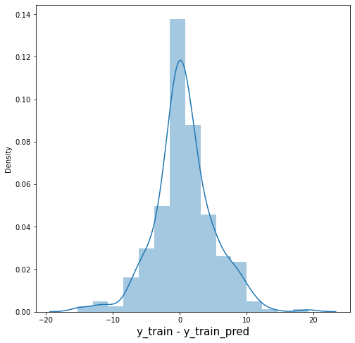

```python
# Plotting the distribution of the residuals to check for Normality

tofig = plt.figure(figsize=(8,8))
sns.distplot(res_trans, bins = 15)
fig.suptitle('Error Terms', fontsize = 15)
plt.xlabel('y_train - y_train_pred', fontsize = 15)
plt.show()
```

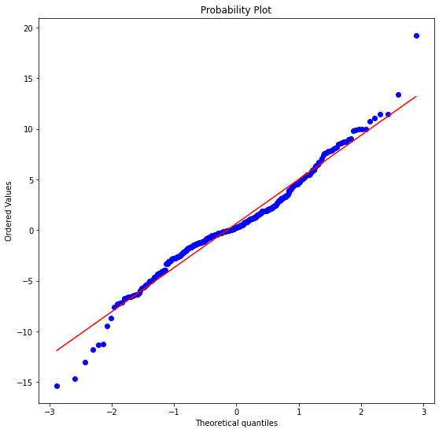

```python
# Q-Q plot for the residuals to check the normality

plt.figure(figsize=(9,9))

stats.probplot(res_trans.squeeze(), dist="norm", plot=plt);
```

```python
# Adding the intercept for the test data of transformed y variable
X_test_sm_trans = sm.add_constant(X_test_trans)

# Predict the y values corresponding to X_test_sm
y_pred_trans = lr.predict(X_test_sm_trans)
```

```python
# Taking the inverse transform of power transform to bring the predictions on test data to original value for comparison

ori_y_test = pt.inverse_transform(np.array(y_pred_trans).reshape(-1, 1))
```

```python
# RMSE calculation on test data for transformed Y model

print('RMSE for the test data for transformed Y is', np.sqrt(mean_squared_error(y_test_trans['Y'], ori_y_test)))
```

```
RMSE for the test data for transformed Y is 4.259302395319205
```

```python
# R2 squared for the transformed Y variable for test data

r_squared_trans = r2_score(y_test_trans['Y'], ori_y_test)
r_squared_trans
```

```
0.5248575866393991
```

# Approach for the Analysis

To start with I looked at the data which was only 2 variables 1 Independent and 1 Dependent variable. Loading the data to understand it better before jumping to fit a trend line was important.

The very 1st steps I follow during the data exploration is to ensure there are no null values, look for any outliers in the data using boxplots or z-score approach or use domain knowledge to make the data clean of outliers. For this data, I went ahead with creating histograms, histograms to visually see the distribution of data along with calculating the skewness for checking Normality. After that I checked for relationship between the X and the Y variables using scatter plot along with correlation coefficient value.

Statmodels library regression output gives a lot more information other than R2 and coeffcients values so decided to go with it initially and later on compare it with the results obtained from Sklearn library regression model.

Once the trend line was fitted and the slope, intercept values came out to be same for the libraries models, I went ahead with addressing a problem I saw earlier with Dependent Variable being Right Skewed.

To solve the skewed Y variable problem, I initially tried Box Cox Transformation to find the lambda value for transforming Y variable. But for Box Cox Transformation all the values needed to be positive for Y variable, so instead I used Power Transformer from Sklearn preprocessing module to transform the Y variable automatically using the Yeo-Johnson method which works for both positive and negative values.

Build a Statsmodels Regression model on Transformed Y and tested it on R2, RMSE for train and test data which performed almost the same as previous model.

In general, for any problem I always try to follow CRISP-DM approach by first understanding the data throughly, most important step being Data Cleaning involving imputing missing values, outlier treatment, exploring the data for hidden patterns using EDA, feature engineering to create new features to enahnce model performance, preprocessing the data as required by the ML algorithms including one hot encoding, label encoding, scaling to build ML algorithms starting first with simpler models such as Logistic/Linear Regression, Naive Bayes and moving ahead with Random Forests, Gradient Boosting later on the in the process. Training these models, hyper tuning hyperparamters, evaluating the model's performance on test data using the appropriate metric such as Recall, Precision, Accuracy to make generalized predictions. Based on the problem to be solved like regression or classification, size of the data and other factors different ML algorithms could be choosen and fine tuned to give generalized prediction.

# Interesting Findings and Final Conclusion